# Turnagain Arm Community Council Land Analysis

## Alaska Statistical Automation (hans.thompson1@gmail.com)

[figure not shown]

This is a generated document for the Turnagain Arm area. The property tax information data from 2014 was joined with the spatial data for parcels in the Anchorage area and spatially filtered for only parcels within the borders of the community council.  
My intention with this document is to demostrate automated report generation with **Alaska Statistical Automation**, my private business for servicing the IT and data management needs in Alaska. If you have a project that might be an interesting project I would love to hear about it. Email me at *hans.thompson1@gmail.com* or call at 360-628-3860. We are located in downtown Anchorage. This document is provided for fun only and should not be used in investment decisions. If you would like to use this data for a futher analysis of investment opportunities. Please contact us!  
I f you feel there is an interesting visualization that could be done with this information that could add to this report please let me know and I would be happy to try and include it across all areas.

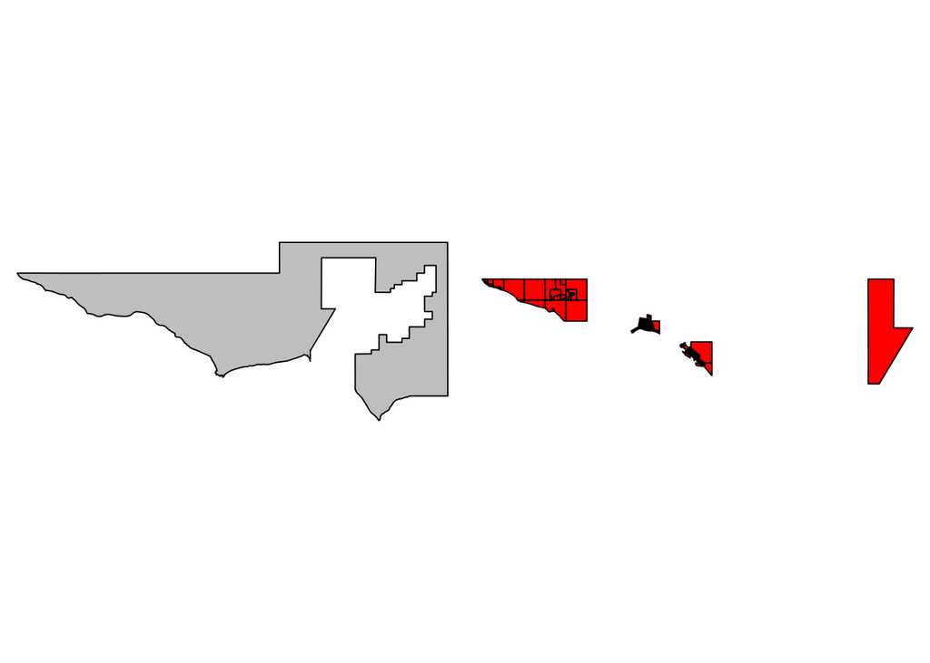

[figure not shown]

[interactive chart not shown]

# Residential Breakdown

### Definitions of different zoning names can be found [Here](http://www.muni.org/Departments/OCPD/Planning/zoning/Pages/ZoningDistricts.aspx)

[figure not shown]

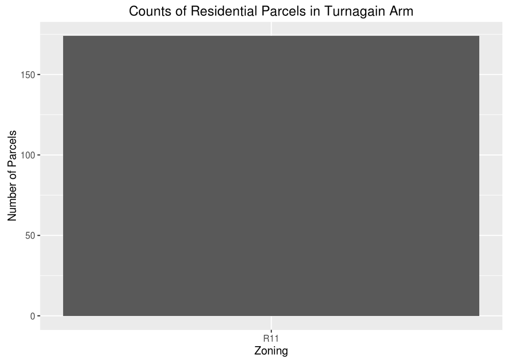

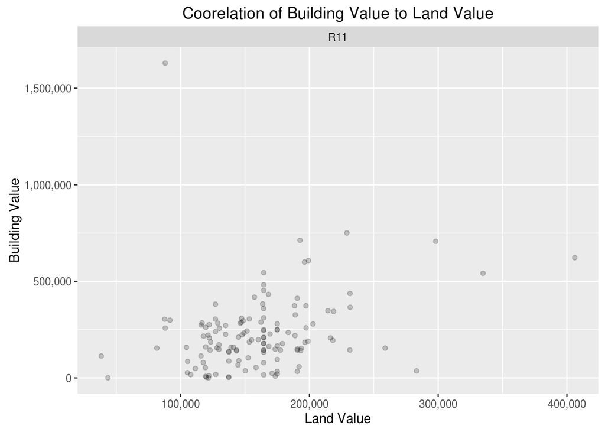

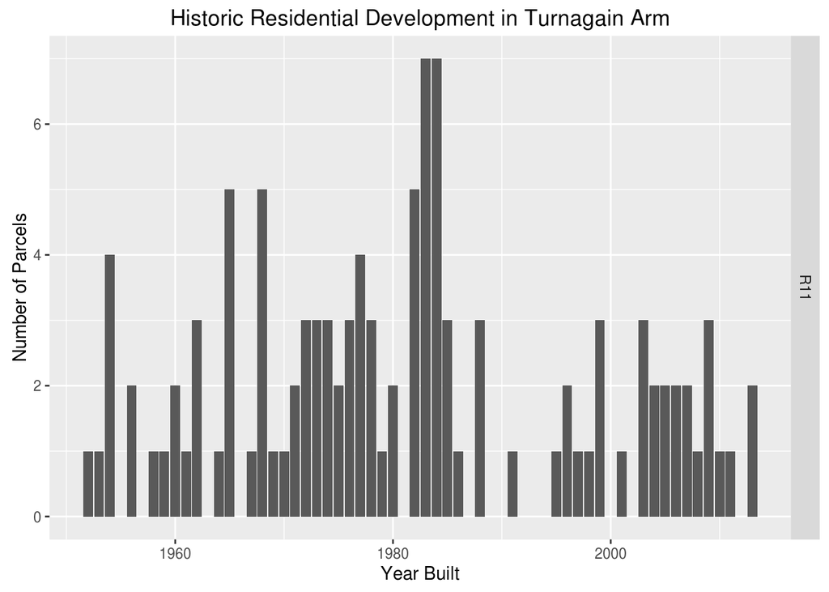

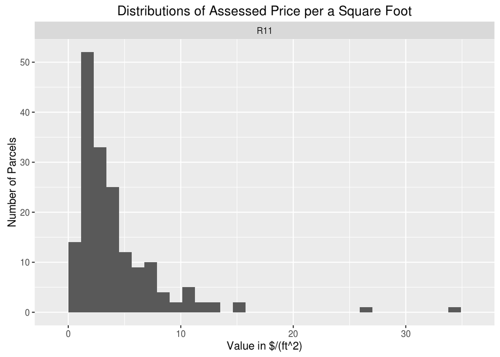